# Problema 4 - Checkpoint 3

```r
library(dplyr, warn.conflicts = F)
library(readr)
library(resample)
library(ggplot2)
dados = read_csv("github-users-committing-filetypes.csv")
```

Continuando a análise anterior, vamos responder mais duas perguntas sobre os dados de commits dos usuários no GitHub.

A primeira pergunta que vamos responder é: Java ou C++ durante a semana?

Essa pergunta pode ajudar a nos mostrar qual dessas duas grandes linguagens OO está mais popular no mercado.

Primeiramento, vamos criar datasets separados para estas duas linguagens.

```r
dados$date <- paste(dados$month_day,dados$the_month, dados$the_year, sep = "-")

dados = dados %>%
  mutate(weekday = weekdays(as.Date(date,'%d-%m-%Y')))

dados = dados %>%
  mutate(isFDS = weekday %in% c("domingo", "sábado"))

dados.java.dds = dados %>% filter(file_extension == "java") %>% filter(!isFDS)
dados.cpp.dds = dados %>% filter(file_extension %in% c("cc", "cpp")) %>% filter(!isFDS)
```

Novamente, como nós estamos trabalhando com uma amostra de dados, vamos aplicar o bootstrapping e calcular o intervalo de confiança.

Para Java, temos o seguinte intervalo de confiança:

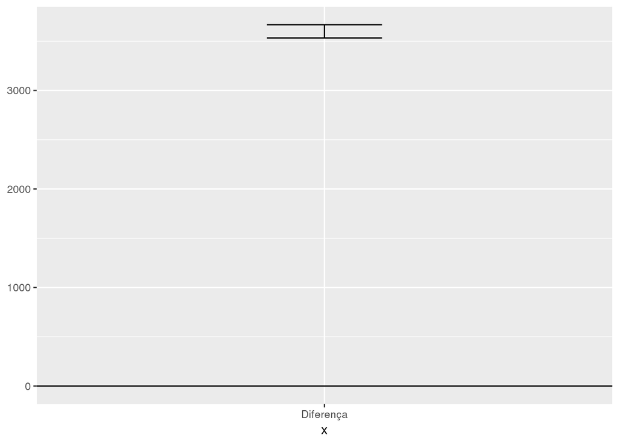

```r
medianas.java.dds = bootstrap(dados.java.dds$users, median,R = 10000)
medianas.java.dds.ci = CI.percentile(medianas.java.dds, probs = c(.025, .975))

data.frame(medianas.java.dds.ci) %>%
  ggplot(aes(x = "Diferença", ymin = X2.5., ymax = X97.5.)) +
  geom_errorbar(width = .2) +
  geom_hline(yintercept = 0)
```

Já para C++:

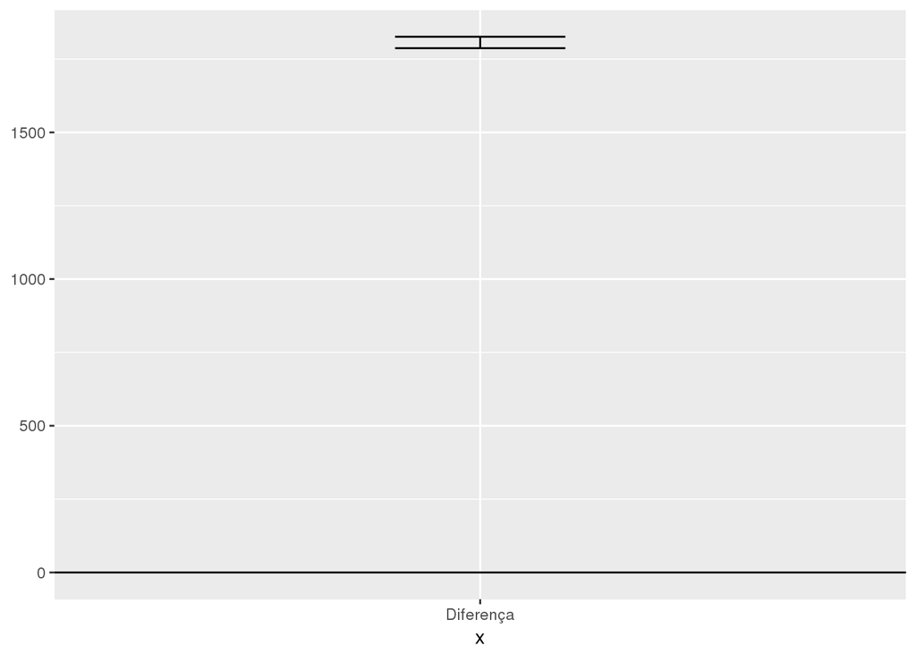

```r
medianas.cpp.dds = bootstrap(dados.cpp.dds$users, median,R = 10000)
medianas.cpp.dds.ci = CI.percentile(medianas.cpp.dds, probs = c(.025, .975))

data.frame(medianas.cpp.dds.ci) %>%
  ggplot(aes(x = "Diferença", ymin = X2.5., ymax = X97.5.)) +
  geom_errorbar(width = .2) +
  geom_hline(yintercept = 0)
```

```r
df <- data.frame(rbind(medianas.java.dds.ci,
                       medianas.cpp.dds.ci))
```

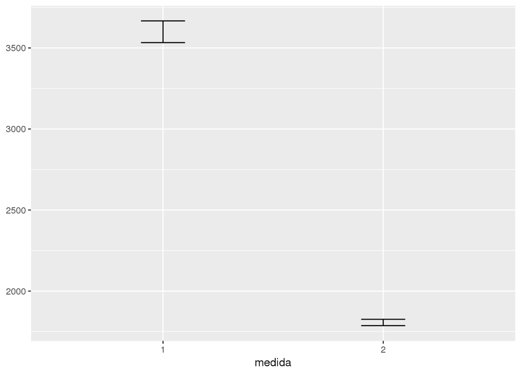

```r
df$medida = row.names(df)

df %>%
  ggplot(aes(x = medida, ymin = X2.5., ymax = X97.5.)) +
  geom_errorbar(width = .2)
```

Comoé possível ver, temos dois intervalos de confiança que não se sobrepõe, onde o de Java é 3533-3666 e C++ é 1787-1826. A partir disso, podemos afirmar com 95% de confiança que Java é mais popular do que C++ durante a semana, o que mostra a força de Java no mercado.

Podemos extender um pouco a pergunta e passar pro final de semana. Será que o comportamento se equipara e temos Java como a mais popular das duas no final de semana também?

Para Java:

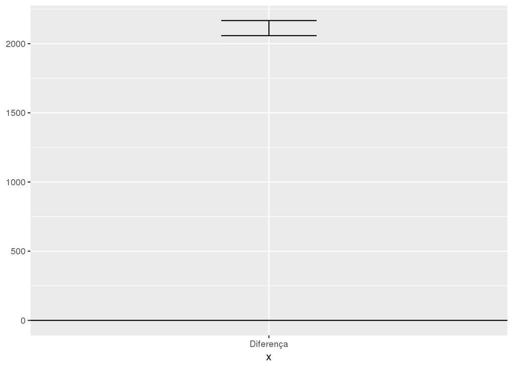

```r
dados.java.fds = dados %>% filter(file_extension == "java") %>% filter(isFDS)
dados.cpp.fds = dados %>% filter(file_extension %in% c("cc", "cpp")) %>% filter(isFDS)

medianas.java.fds = bootstrap(dados.java.fds$users, median,R = 10000)
medianas.java.fds.ci = CI.percentile(medianas.java.fds, probs = c(.025, .975))

data.frame(medianas.java.fds.ci) %>%
  ggplot(aes(x = "Diferença", ymin = X2.5., ymax = X97.5.)) +
  geom_errorbar(width = .2) +
  geom_hline(yintercept = 0)
```

Para C++:

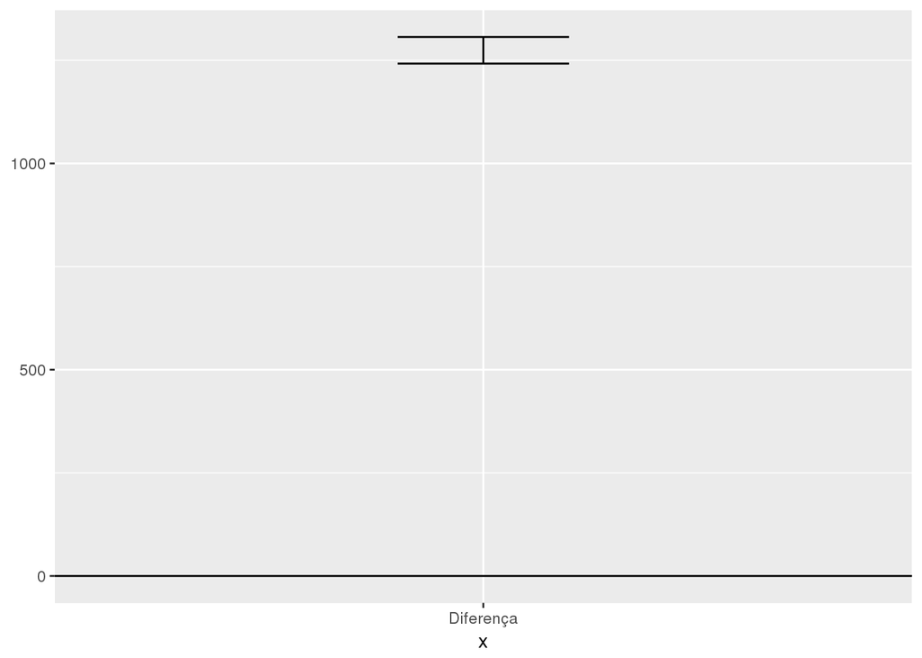

```r
medianas.cpp.fds = bootstrap(dados.cpp.fds$users, median,R = 10000)
medianas.cpp.fds.ci = CI.percentile(medianas.cpp.fds, probs = c(.025, .975))

data.frame(medianas.cpp.fds.ci) %>%
  ggplot(aes(x = "Diferença", ymin = X2.5., ymax = X97.5.)) +
  geom_errorbar(width = .2) +
  geom_hline(yintercept = 0)
```

```r
df <- data.frame(rbind(medianas.java.fds.ci,
                       medianas.cpp.fds.ci))
```

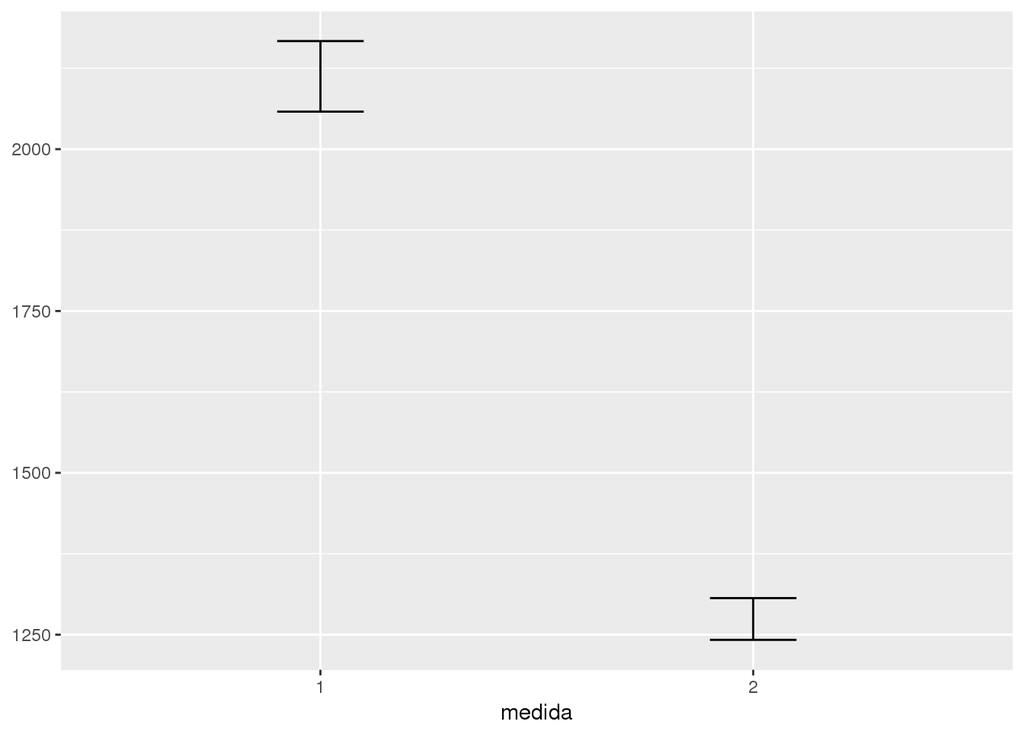

```r
df$medida = row.names(df)

df %>%
  ggplot(aes(x = medida, ymin = X2.5., ymax = X97.5.)) +
  geom_errorbar(width = .2)
```

Mais uma vez, podemos ver pelos gráficos que o intervalo de confiança de Java e C++ não tem interseção, logo há uma diferença considerável entre ambos, com Java mais uma vez sendo mais popular que C++.

A segunda pergunta que vamos responder é: A produtividade dos desenvolvedores é maior na terça, quarta e quinta do que na segunda e sexta?

```r
dados.tqq = dados %>%
  filter(weekday %in% c("terça", "quarta", "quinta"))

dados.ses = dados %>%
  filter(weekday %in% c("segunda", "sexta"))
```

Vamos calcular a mediana da quantidade de commits nesses dois intervalos da semana, aplicando o bootsrapping novamente para aumentar o nível de confiança dos dados.

Para a Terça, Quarta e Quinta, temos a seguinte mediana, com 95% de confiança que este comportamento se reproduz nas estatísticas gerais:

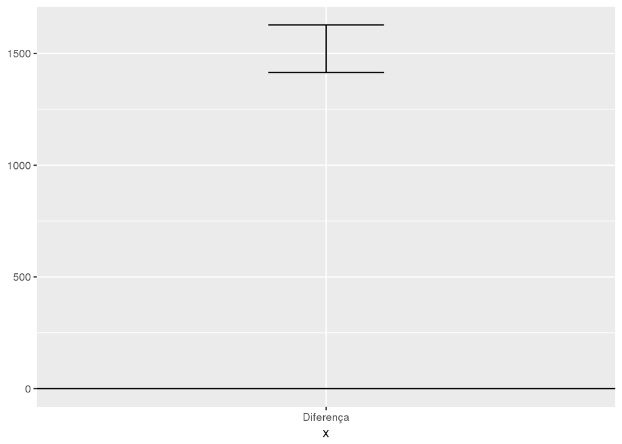

```r
medianas.tqq = bootstrap(dados.tqq$users, median,R = 10000)
medianas.tqq.ci = CI.percentile(medianas.tqq, probs = c(.025, .975))

data.frame(medianas.tqq.ci) %>%
  ggplot(aes(x = "Diferença", ymin = X2.5., ymax = X97.5.)) +
  geom_errorbar(width = .2) +
  geom_hline(yintercept = 0)
```

Já para a segunda e sexta:

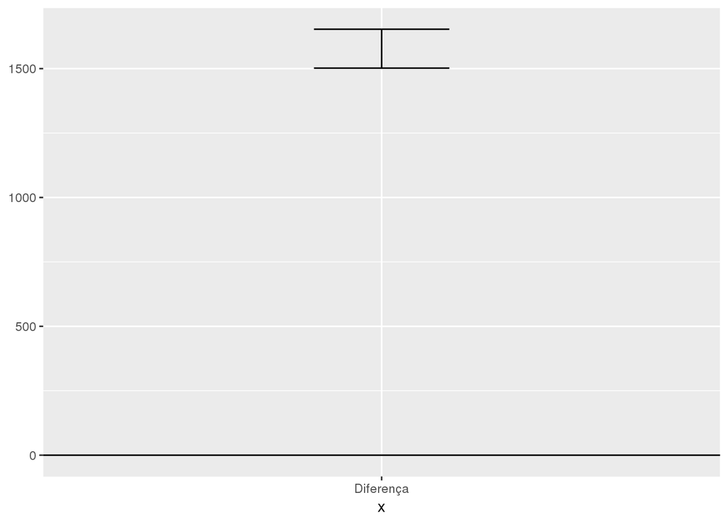

```r
medianas.ses = bootstrap(dados.ses$users, median,R = 10000)
medianas.ses.ci = CI.percentile(medianas.ses, probs = c(.025, .975))

data.frame(medianas.ses.ci) %>%
  ggplot(aes(x = "Diferença", ymin = X2.5., ymax = X97.5.)) +
  geom_errorbar(width = .2) +
  geom_hline(yintercept = 0)
```

```r
df <- data.frame(rbind(medianas.tqq.ci,
                       medianas.ses.ci))
```

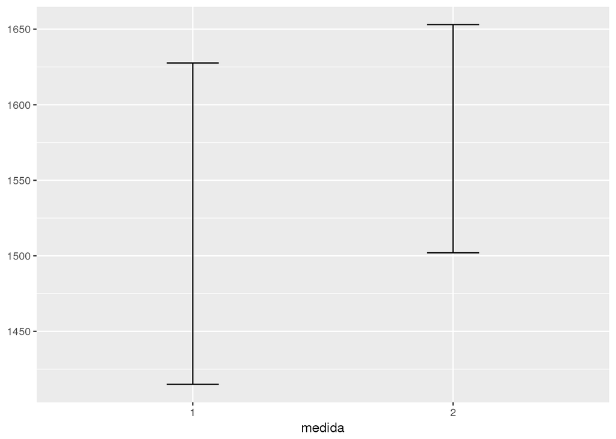

```r
df$medida = row.names(df)

df %>%
  ggplot(aes(x = medida, ymin = X2.5., ymax = X97.5.)) +
  geom_errorbar(width = .2)
```

```r
dados.segunda = dados %>%
  filter(weekday == "segunda")

dados.sexta = dados %>%
  filter(weekday == "sexta")
```

Vamos agora calcular a mediana da quantidade de commits nesses dois dias da semana:

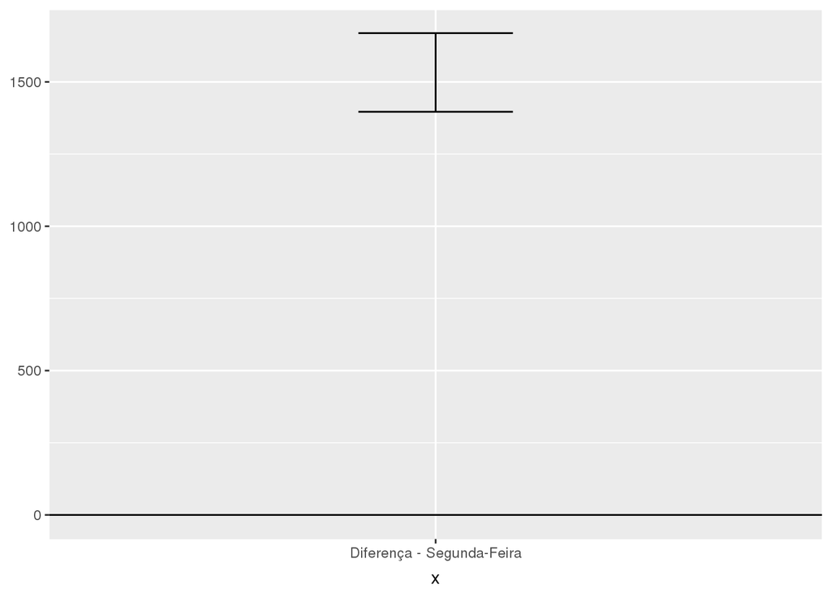

```r
medianas.segunda = bootstrap(dados.segunda$users, median,R = 10000)
medianas.segunda.ci = CI.percentile(medianas.segunda, probs = c(.025, .975))

data.frame(medianas.segunda.ci) %>%
  ggplot(aes(x = "Diferença - Segunda-Feira", ymin = X2.5., ymax = X97.5.)) +
  geom_errorbar(width = .2) +
  geom_hline(yintercept = 0)
```

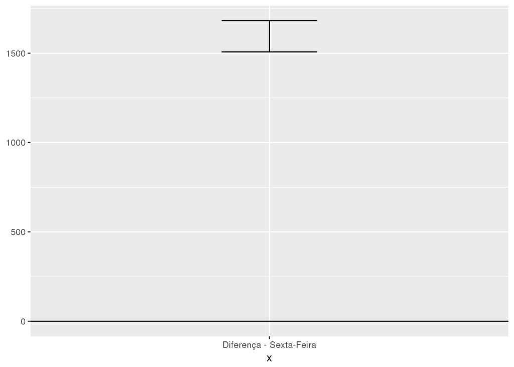

```r
medianas.sexta = bootstrap(dados.sexta$users, median,R = 10000)
medianas.sexta.ci = CI.percentile(medianas.sexta, probs = c(.025, .975))

data.frame(medianas.sexta.ci) %>%
  ggplot(aes(x = "Diferença - Sexta-Feira", ymin = X2.5., ymax = X97.5.)) +
  geom_errorbar(width = .2) +
  geom_hline(yintercept = 0)
```

Os intervalos da mediana para a segunda e sexta são, respectivamente:

```r
df <- data.frame(rbind(medianas.segunda.ci,
                       medianas.sexta.ci))
```

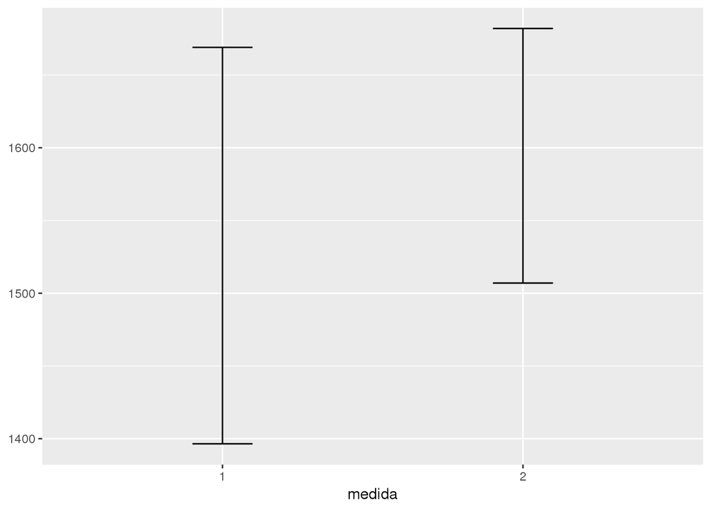

```r
df$medida = row.names(df)

df %>%
  ggplot(aes(x = medida, ymin = X2.5., ymax = X97.5.)) +
  geom_errorbar(width = .2)
```

Como o intervalo possui uma interseção, não podemos afirmar qual dia tem maior produtividade.